# Analyzing the contribution of rainfall variability in Rapoport Effect for Eastern U.S. tree species

Brian Wentzloff

2024-12-13

## Introduction

### Background

Rapoport’s rule states that as latitudes increase, the geographical range of species increases. Morin and Lechowicz have determined that this is not due to physical continental constraints, but is consistent with the climatic variability hypothesis. (Morin, 2011) This hypothesis states that as the climate is more variable, the species in that environment need to be adapted to handle the more extreme ends of the climate spectrum, thereby allowing them to increase range size since they are better equipped to handle variability. The reason these studies are interesting is that as our planet’s climate continues to change, it will be helpful to know the effect of that change on range sizes for current species.

Pintor et al investigated the effect of temperature variations on several species in Australia. Their results supported the climatic variability hypothesis as a mechanism for Rapoport’s Rule. Their study investigated both average temperatures as well as minimums and maximums to determine an accurate temperature variation gradient. (Pintor, 2015)

Zhu et al investigated migrations due to climate change by looking at juvenile and adult tree abundances. They were attempting to determine any migration lag in the expansion of tree ranges. In order to do this, they used a measure called abundance which was calculated using the area’s mean temperature and rainfall. (Zhu, 2014)

While it is interesting that Zhu considered the amount of rainfall in species range, they used mean figures for rainfall. Rapoport’s Rule deals with variability of climate variables. Therefore, it would be interesting to run a similar analysis as Pintor’s team, but look at precipitation extremes to determine if it is consequential in Eastern U.S. tree species ranges.

### Hypothesis

My hypothesis is that as rainfall variability increases, the range for a particular tree species will increase.

### Data

This hypothesis can be tested using data from the U.S. Forest Services’ Forest Inventory and Analysis data. It provides grid data in the form of latitudes and longitudes and (among other things) low, mean, and high precipitation amounts for each grid parcel.

## Methods

To test this hypothesis, FIA data was used to first plot the ranges of particular species. Shape files were used to plot the Eastern United States on a graph of longitude and latitude. The shape files contained the entire U.S. so they were filtered to only study the Eastern U.S.

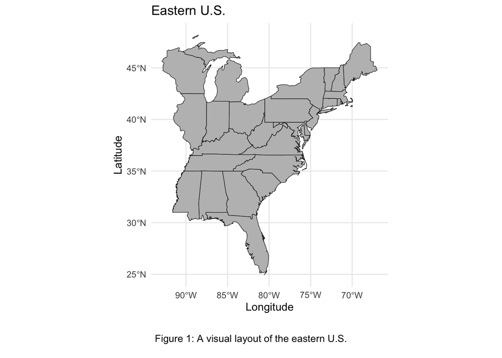

```r
# load the necessary libraries for entire script.
library(dplyr)
library(tidyr)
library(ggplot2)
library(rnaturalearth)
library(rnaturalearthdata)
library(classInt)
library(gridExtra)
library(sf)
library(patchwork)
library(eHOF)

# read in the shape files as a list
usa_states <- st_read("~/stateshapes/states.shp")

# filter the eastern states
selected_states <- usa_states %>%
  filter(STATE_NAME %in% c("Alabama", "Connecticut", "Delaware", "Florida", "Georgia", "Illinois", "Indiana", "Kentucky", "Maine", "Maryland", "Massachusetts", "Michigan", "Mississippi", "New Hampshire", "New Jersey", "New York", "North Carolina", "Ohio", "Pennsylvania", "Rhode Island", "South Carolina", "Tennessee", "Vermont", "Virginia", "West Virginia", "Wisconsin"))

# plot latitude vs. longitude
plot <- ggplot() +
  geom_sf(data = selected_states, fill = "grey", color = "black") +
  theme_minimal() +
  labs(title = "Eastern U.S.",x = "Longitude", y = "Latitude")

caption <- grid::textGrob("Figure 1: A visual layout of the eastern U.S.", gp = grid::gpar(fontsize = 10), hjust = 0.5)
final_plot <- gridExtra::grid.arrange(plot, caption, ncol = 1, heights = c(4, 0.5))
```

Ranges for the various tree species in the FIA data could then be plotted on the map of the eastern U.S. Here is the range of the sweetgum species, which primarily exists in the southern part of the eastern U.S.:

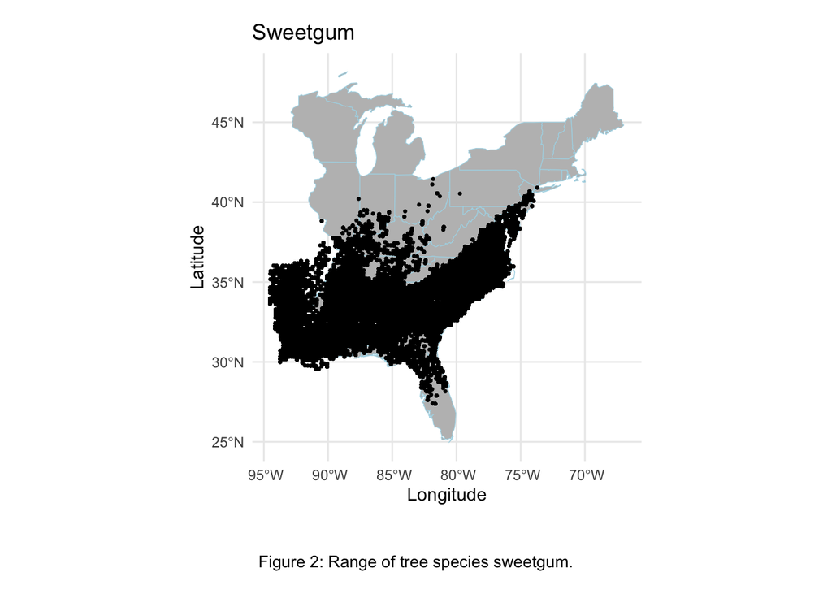

```r
species_name = "sweetgum"
raw_data <- readRDS("~/FIA_tree_master1.RDS")
single_species_grouped_by_name <- raw_data %>%
  group_by(COMMON_NAME) %>%
  filter(COMMON_NAME == species_name)

plot <- ggplot() +
  geom_sf(data = selected_states, fill = "grey", color = "lightblue") +
  geom_point(data = single_species_grouped_by_name, aes(x = LON, y = LAT), size = 0.5) +
  theme_minimal() +
  labs(title = "Sweetgum",x = "Longitude", y = "Latitude") +
  theme(plot.margin = grid::unit(c(1, 1, 1, 1), "lines"))

caption <- grid::textGrob("Figure 2: Range of tree species sweetgum.", gp = grid::gpar(fontsize = 10), hjust = 0.5)

final_plot <- gridExtra::grid.arrange(plot, caption, ncol = 1, heights = c(4, 0.5))
```

Next, the variability of precipitation within that range can be calculated by the simple equation `maxiumum precipitation - minimum precipitation`

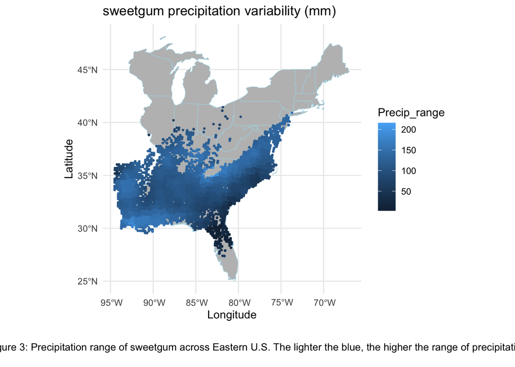

```r
species_name = "sweetgum"
# group by species and add calculated column precipitation range
raw_data <- readRDS("~/FIA_tree_master1.RDS")
single_species_grouped_by_name <- raw_data %>%
  group_by(COMMON_NAME) %>%
  filter(COMMON_NAME == species_name) %>%
  mutate(Precip_range = abs(Precip_wet - Precip_dry))

plot <- ggplot() +
  geom_sf(data = selected_states, fill = "grey", color = "lightblue") +
  geom_point(data = single_species_grouped_by_name, aes(x = LON, y = LAT, color=Precip_range), size = 0.5) +
  theme_minimal() +
  labs(title = paste(species_name,"precipitation variability (mm)"),x = "Longitude", y = "Latitude")

caption <- grid::textGrob("Figure 3: Precipitation range of sweetgum across Eastern U.S. The lighter the blue, the higher the range of precipitation", gp = grid::gpar(fontsize = 10), hjust = 0.5)

final_plot <- gridExtra::grid.arrange(plot, caption, ncol = 1, heights = c(4, 0.5))
```

Now that there is a latitude associated with precipitation range data, latitudes were divided into 0.5 degree bands. For each band, the moving average precipitation variability for that entire band was calculated. The results were scaled and a model of best fit was determined:

```r
hof_plot <- function(species, simple_title=FALSE, return_intercept=FALSE){
  # group by species and add calculated column precipitation range
  single_species_grouped_by_name <- raw_data %>%
    group_by(COMMON_NAME) %>%
    filter(COMMON_NAME == species) %>%
    mutate(Precip_range = abs(Precip_wet - Precip_dry))

  # 0.5 degree bands with a moving average of 1.0 degree for each band
  lat_seq <- seq(from = floor(min(single_species_grouped_by_name$LAT)), to = ceiling(max(single_species_grouped_by_name$LAT)), by = 0.5)
  bands <- data.frame(
    Lat_band = lat_seq,
    precip_range = numeric(length(lat_seq))
  )

  for (i in 1:length(lat_seq)){
    lat_min <- lat_seq[i] - 0.5
    lat_max <- lat_seq[i] + 0.5
    band_data <- single_species_grouped_by_name %>%
      filter(LAT >= lat_min & LAT <= lat_max)
    bands$precip_range[i] <- mean(band_data$Precip_range, na.rm = TRUE)
  }
  bands <- bands[complete.cases(bands$precip_range),]
  hof_model <- HOF(
    bands$precip_range,
    bands$Lat_band,
    modeltypes = c("I","II","III","IV","V"),
    family = gaussian,
    bootstrap = 100,
    test = 'AIC'
  )
  best_model <- pick.model(hof_model, modeltypes = c("I","II","III","IV","V"), test = 'AIC')
  predicted_response <- predict(hof_model, model = best_model,
                                newdata = seq(min(bands$Lat_band), max(bands$Lat_band), by = 0.1))
  scaled_response <- predicted_response * max(bands$precip_range)
  if (simple_title) {
    chart_title <- species
    y_label = "prec. var."
  } else {
    chart_title <- paste("Latitudinal Precipitation variability pattern", species)
    y_label = "Precipitation variability"
  }
  plot <- ggplot(bands, aes(x = Lat_band, y = precip_range)) +
    geom_point(color = "grey60") +
    geom_line(data = data.frame(lat_band = seq(min(bands$Lat_band),
                                               max(bands$Lat_band), by = 0.1),
                                predicted_IV = scaled_response),
              aes(x = lat_band, y = predicted_IV), color = "black") +
    geom_vline(xintercept = Para(hof_model, model = best_model)$opt, color = "red", linetype = "dashed") +
    labs(title = chart_title, x = "latitude", y = y_label)

  caption <- grid::textGrob("Figure 4: Sweetgum precipitation range vs. Latitude", gp = grid::gpar(fontsize = 10), hjust = 0.5)

  final_plot <- gridExtra::grid.arrange(plot, caption, ncol = 1, heights = c(4, 0.5))

  if (return_intercept) {
    return(Para(hof_model, model = best_model)$opt)
  } else {
    print(plot)
  }
}
```

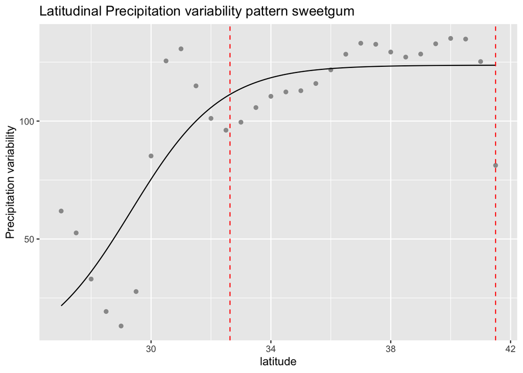

```r
hof_plot("sweetgum")
```

Now, this process can be run with all species that have more than 30000 data points in our data.

```r
# limit to species with above 30000 samples
all_species <- raw_data %>%
  group_by(COMMON_NAME) %>%
  summarise(Count = n()) %>%
  filter(Count > 30000) %>%
  arrange(desc(Count))

# store all plots to a list
plots <- lapply(all_species$COMMON_NAME, hof_plot, simple_title=TRUE)
```

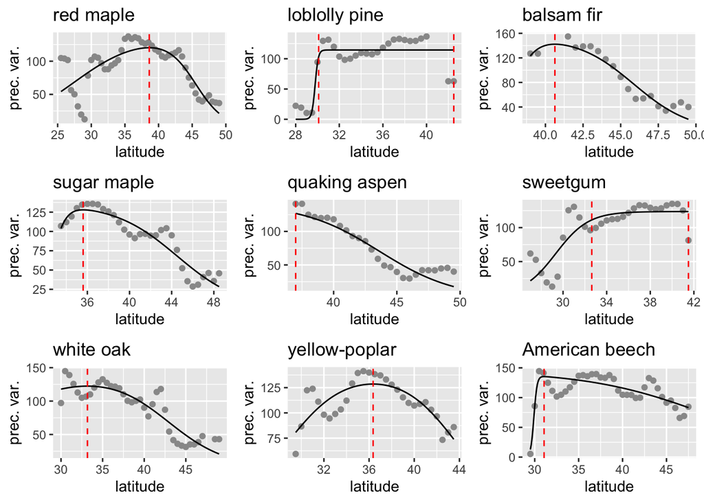

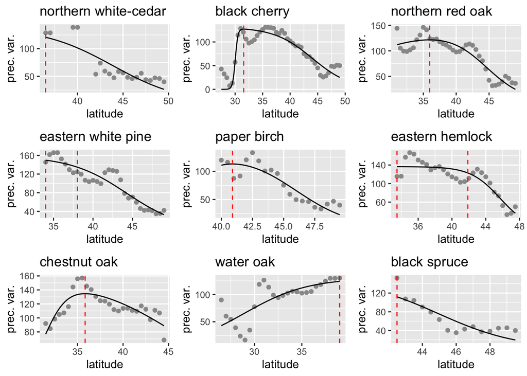

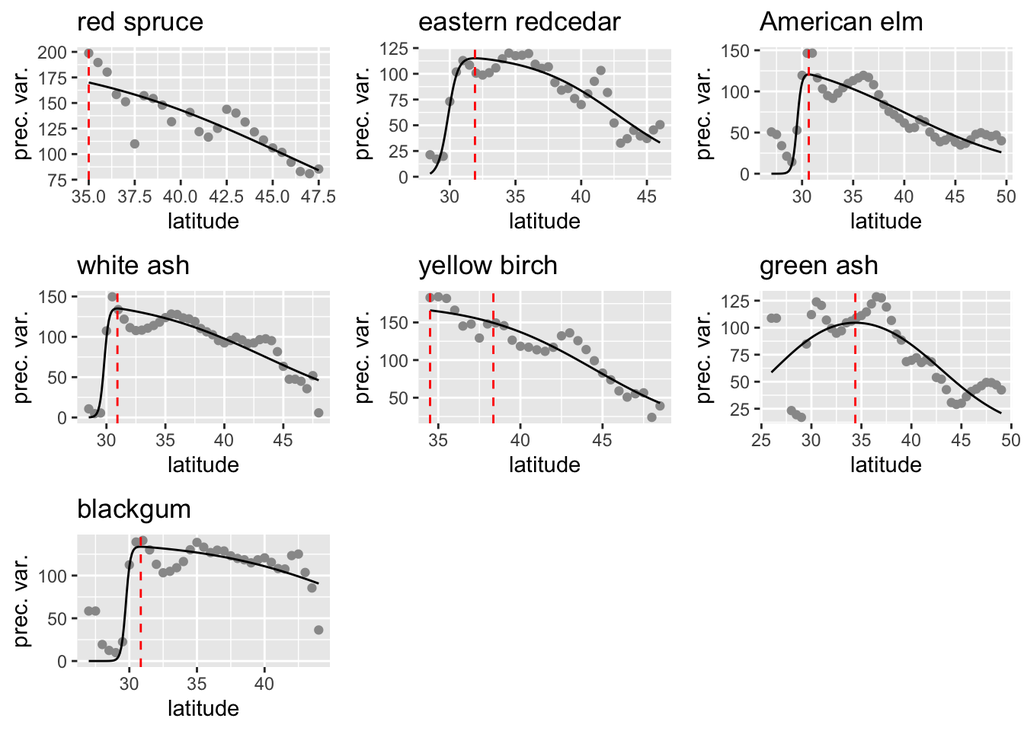

```r
# arrange 9 to a page
for (i in seq(1,length(plots), by = 9)){
  grid.arrange(
    grobs = plots[i : min(i + 8, length(plots))],
    ncol = 3,
    nrow = 3
  )
}
```

## Results

### Precipitation variability vs. latitude

As can be seen in the results above, many of the species increase the amount of precipitation variability they have as latitude increases, but only up to a point. It can be seen that most species have a point where they stop increasing and start decreasing. To determine if that inversion point was consistent across species, a data frame with each species’ x intercept was created and the results are below.

```r
all_species <- raw_data %>%
  group_by(COMMON_NAME) %>%
  summarise(Count = n()) %>%
  filter(Count > 30000) %>%
  arrange(desc(Count))

intercepts <- data.frame(
  name = all_species$COMMON_NAME,
  intercept = numeric(nrow(all_species))
)

for (i in 1:nrow(all_species)){
  response <- hof_plot(all_species$COMMON_NAME[i], return_intercept=TRUE)
  if (length(response) > 1) {
    intercepts$intercept[i] <- response[[2]]
  } else {
    intercepts$intercept[i] <- response[1]
  }
}
```

```r
summary(intercepts$intercept)
```

```
##    Min. 1st Qu.  Median    Mean 3rd Qu.    Max.
##   30.66   32.01   35.83   35.75   38.35   42.50
```

### Comparison to other abiotic factors

Other abiotic factors that we know can be used to determine the importance of the precipitation variation seen above. The entire process was run again using temperature ranges instead. The results are below.

```r
hof_plot_temp <- function(species, simple_title=FALSE, return_intercept=FALSE){
  single_species_grouped_by_name <- raw_data %>%
    group_by(COMMON_NAME) %>%
    filter(COMMON_NAME == species) %>%
    mutate(Precip_range = Temp_warm - Temp_cold)
  red_maple_data <- single_species_grouped_by_name %>%
    filter(COMMON_NAME == species)
  red_maple_data
  lat_seq <- seq(from = floor(min(red_maple_data$LAT)), to = ceiling(max(red_maple_data$LAT)), by = 0.5)
  lat_seq
  bands <- data.frame(
    Lat_band = lat_seq,
    avg_IV = numeric(length(lat_seq))
  )
  bands
  for (i in 1:length(lat_seq)){
    lat_min <- lat_seq[i] - 0.5
    lat_max <- lat_seq[i] + 0.5
    band_data <- red_maple_data %>%
      filter(LAT >= lat_min & LAT <= lat_max)
    bands$avg_IV[i] <- mean(band_data$Precip_range, na.rm = TRUE)
  }
  bands
  bands <- bands[complete.cases(bands$avg_IV),]
  bands
  hof_model <- HOF(
    bands$avg_IV,
    bands$Lat_band,
    modeltypes = c("I","II","III","IV","V"),
    family = gaussian,
    bootstrap = 100,
    test = 'AIC'
  )
  best_model <- pick.model(hof_model, modeltypes = c("I","II","III","IV","V"), test = 'AIC')
  predicted_response <- predict(hof_model, model = best_model,
                                newdata = seq(min(bands$Lat_band), max(bands$Lat_band), by = 0.1))
  scaled_response <- predicted_response * max(bands$avg_IV)
  if (simple_title) {
    chart_title <- species
    y_label = "prec. var."
  } else {
    chart_title <- paste("Latitudinal Precipitation variability pattern", species)
    y_label = "Precipitation variability"
  }
  final_plot <- ggplot(bands, aes(x = Lat_band, y = avg_IV)) +
    geom_point(color = "grey60") +
    geom_line(data = data.frame(lat_band = seq(min(bands$Lat_band),
                                               max(bands$Lat_band), by = 0.1),
                                predicted_IV = scaled_response),
              aes(x = lat_band, y = predicted_IV), color = "black") +
    geom_vline(xintercept = Para(hof_model, model = best_model)$opt, color = "red", linetype = "dashed") +
    labs(title = chart_title, x = "latitude", y = y_label)
  return_intercept<-FALSE
  if (return_intercept) {
    return(Para(hof_model, model = best_model)$opt)
  } else {
    print(final_plot)
  }
}

all_species <- raw_data %>%
  group_by(COMMON_NAME) %>%
  summarise(Count = n()) %>%
  filter(Count > 30000) %>%
  arrange(desc(Count))

# store all plots to a list
plots <- lapply(all_species$COMMON_NAME, hof_plot_temp, simple_title=TRUE)
```

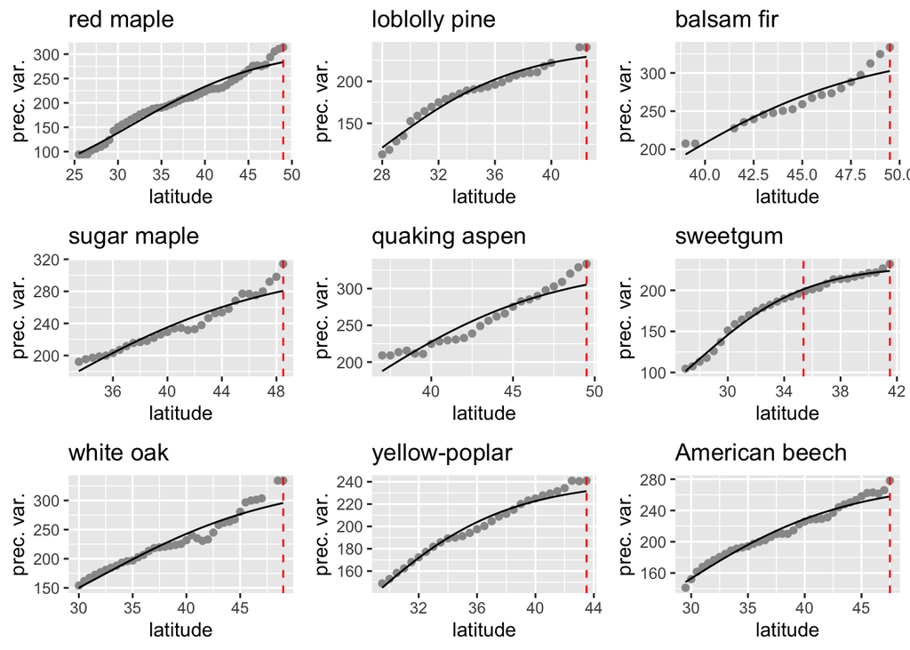

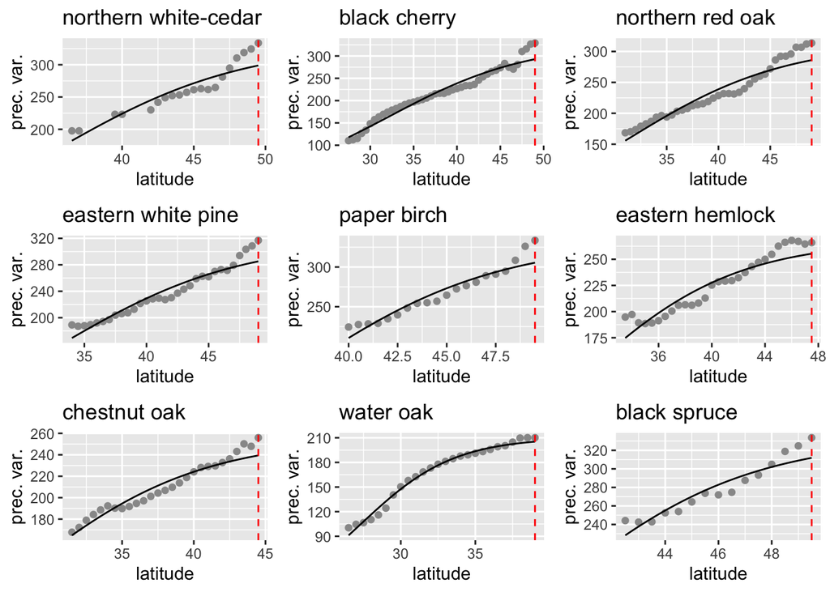

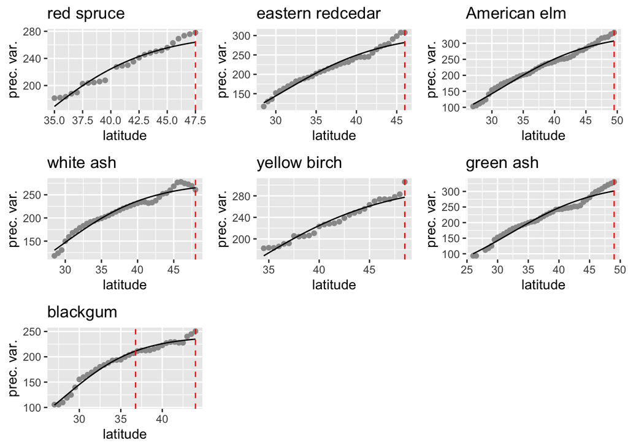

```r
# arrange 9 to a page
for (i in seq(1,length(plots), by = 9)){
  grid.arrange(
    grobs = plots[i : min(i + 8, length(plots))],
    ncol = 3,
    nrow = 3
  )
}
```

## References

Morin, X., & Lechowicz, M. J. (2011). Geographical and ecological patterns of range size in North American trees. Ecography, 34(6), 738-750. https://doi.org/10.1111/j.1600-0587.2010.06854.x

Pintor, A. F. V., Schwarzkopf, L., & Krockenberger, A. K. (2015). Rapoport’s Rule: Do climatic variability gradients shape range extent? Ecological Monographs, 85(4), 643-659. https://doi.org/10.1890/14-1643.1

Zhu, K., Woodall, C. W., Ghosh, S., Gelfand, A. E., & Clark, J. S. (2014). Dual impacts of climate change: Forest migration and turnover through life history. Global Change Biology, 20(1), 251-264. https://doi.org/10.1111/gcb.12382